# EDA project

```python
import pandas as pd
import numpy as np
import seaborn as sns
import matplotlib.pyplot as plt
import warnings
warnings.filterwarnings("ignore")
```

```python
df=pd.read_csv(r"C:\Users\najee\Downloads\sales_data.csv\sales_data.csv")
```

```python
df
```

|  | Date | Day | Month | Year | Customer_Age | Age_Group | Customer_Gender | Country | State | Product_Category | Sub_Category | Product | Order_Quantity | Unit_Cost | Unit_Price | Profit | Cost | Revenue |
| --- | --- | --- | --- | --- | --- | --- | --- | --- | --- | --- | --- | --- | --- | --- | --- | --- | --- | --- |
| 0 | 2013-11-26 | 26 | November | 2013 | 19 | Youth (<25) | M | Canada | British Columbia | Accessories | Bike Racks | Hitch Rack - 4-Bike | 8 | 45 | 120 | 590 | 360 | 950 |
| 1 | 2015-11-26 | 26 | November | 2015 | 19 | Youth (<25) | M | Canada | British Columbia | Accessories | Bike Racks | Hitch Rack - 4-Bike | 8 | 45 | 120 | 590 | 360 | 950 |
| 2 | 2014-03-23 | 23 | March | 2014 | 49 | Adults (35-64) | M | Australia | New South Wales | Accessories | Bike Racks | Hitch Rack - 4-Bike | 23 | 45 | 120 | 1366 | 1035 | 2401 |
| 3 | 2016-03-23 | 23 | March | 2016 | 49 | Adults (35-64) | M | Australia | New South Wales | Accessories | Bike Racks | Hitch Rack - 4-Bike | 20 | 45 | 120 | 1188 | 900 | 2088 |
| 4 | 2014-05-15 | 15 | May | 2014 | 47 | Adults (35-64) | F | Australia | New South Wales | Accessories | Bike Racks | Hitch Rack - 4-Bike | 4 | 45 | 120 | 238 | 180 | 418 |
| ... | ... | ... | ... | ... | ... | ... | ... | ... | ... | ... | ... | ... | ... | ... | ... | ... | ... | ... |
| 113031 | 2016-04-12 | 12 | April | 2016 | 41 | Adults (35-64) | M | United Kingdom | England | Clothing | Vests | Classic Vest, S | 3 | 24 | 64 | 112 | 72 | 184 |
| 113032 | 2014-04-02 | 2 | April | 2014 | 18 | Youth (<25) | M | Australia | Queensland | Clothing | Vests | Classic Vest, M | 22 | 24 | 64 | 655 | 528 | 1183 |
| 113033 | 2016-04-02 | 2 | April | 2016 | 18 | Youth (<25) | M | Australia | Queensland | Clothing | Vests | Classic Vest, M | 22 | 24 | 64 | 655 | 528 | 1183 |
| 113034 | 2014-03-04 | 4 | March | 2014 | 37 | Adults (35-64) | F | France | Seine (Paris) | Clothing | Vests | Classic Vest, L | 24 | 24 | 64 | 684 | 576 | 1260 |
| 113035 | 2016-03-04 | 4 | March | 2016 | 37 | Adults (35-64) | F | France | Seine (Paris) | Clothing | Vests | Classic Vest, L | 23 | 24 | 64 | 655 | 552 | 1207 |

113036 rows × 18 columns

```python
df.shape
```

```
(113036, 18)
```

```python
df.size
```

```
2034648
```

```python
df.info()
```

```
<class 'pandas.core.frame.DataFrame'>
RangeIndex: 113036 entries, 0 to 113035
Data columns (total 18 columns):
 #   Column            Non-Null Count   Dtype
---  ------            --------------   -----
 0   Date              113036 non-null  object
 1   Day               113036 non-null  int64
 2   Month             113036 non-null  object
 3   Year              113036 non-null  int64
 4   Customer_Age      113036 non-null  int64
 5   Age_Group         113036 non-null  object
 6   Customer_Gender   113036 non-null  object
 7   Country           113036 non-null  object
 8   State             113036 non-null  object
 9   Product_Category  113036 non-null  object
 10  Sub_Category      113036 non-null  object
 11  Product           113036 non-null  object
 12  Order_Quantity    113036 non-null  int64
 13  Unit_Cost         113036 non-null  int64
 14  Unit_Price        113036 non-null  int64
 15  Profit            113036 non-null  int64
 16  Cost              113036 non-null  int64
 17  Revenue           113036 non-null  int64
dtypes: int64(9), object(9)
memory usage: 15.5+ MB
```

```python
df.dtypes
```

```
Date                object
Day                  int64
Month               object
Year                 int64
Customer_Age         int64
Age_Group           object
Customer_Gender     object
Country             object
State               object
Product_Category    object
Sub_Category        object
Product             object
Order_Quantity       int64
Unit_Cost            int64
Unit_Price           int64
Profit               int64
Cost                 int64
Revenue              int64
dtype: object
```

```python
df.columns
```

```
Index(['Date', 'Day', 'Month', 'Year', 'Customer_Age', 'Age_Group',
       'Customer_Gender', 'Country', 'State', 'Product_Category',
       'Sub_Category', 'Product', 'Order_Quantity', 'Unit_Cost', 'Unit_Price',
       'Profit', 'Cost', 'Revenue'],
      dtype='object')
```

```python
df.describe()
```

|  | Day | Year | Customer_Age | Order_Quantity | Unit_Cost | Unit_Price | Profit | Cost | Revenue |
| --- | --- | --- | --- | --- | --- | --- | --- | --- | --- |
| count | 113036.000000 | 113036.000000 | 113036.000000 | 113036.000000 | 113036.000000 | 113036.000000 | 113036.000000 | 113036.000000 | 113036.000000 |
| mean | 15.665753 | 2014.401739 | 35.919212 | 11.901660 | 267.296366 | 452.938427 | 285.051665 | 469.318695 | 754.370360 |
| std | 8.781567 | 1.272510 | 11.021936 | 9.561857 | 549.835483 | 922.071219 | 453.887443 | 884.866118 | 1309.094674 |
| min | 1.000000 | 2011.000000 | 17.000000 | 1.000000 | 1.000000 | 2.000000 | -30.000000 | 1.000000 | 2.000000 |
| 25% | 8.000000 | 2013.000000 | 28.000000 | 2.000000 | 2.000000 | 5.000000 | 29.000000 | 28.000000 | 63.000000 |
| 50% | 16.000000 | 2014.000000 | 35.000000 | 10.000000 | 9.000000 | 24.000000 | 101.000000 | 108.000000 | 223.000000 |
| 75% | 23.000000 | 2016.000000 | 43.000000 | 20.000000 | 42.000000 | 70.000000 | 358.000000 | 432.000000 | 800.000000 |
| max | 31.000000 | 2016.000000 | 87.000000 | 32.000000 | 2171.000000 | 3578.000000 | 15096.000000 | 42978.000000 | 58074.000000 |

```python
df.nunique()
```

```
Date                1884
Day                   31
Month                 12
Year                   6
Customer_Age          70
Age_Group              4
Customer_Gender        2
Country                6
State                 53
Product_Category       3
Sub_Category          17
Product              130
Order_Quantity        32
Unit_Cost             34
Unit_Price            36
Profit              1256
Cost                 360
Revenue             1876
dtype: int64
```

```python
df.duplicated()
```

```
0         False
1         False
2         False
3         False
4         False
          ...
113031    False
113032    False
113033    False
113034    False
113035    False
Length: 113036, dtype: bool
```

```python
df.duplicated().sum()
```

```
np.int64(1000)
```

```python
df.isnull()
```

|  | Date | Day | Month | Year | Customer_Age | Age_Group | Customer_Gender | Country | State | Product_Category | Sub_Category | Product | Order_Quantity | Unit_Cost | Unit_Price | Profit | Cost | Revenue |
| --- | --- | --- | --- | --- | --- | --- | --- | --- | --- | --- | --- | --- | --- | --- | --- | --- | --- | --- |
| 0 | False | False | False | False | False | False | False | False | False | False | False | False | False | False | False | False | False | False |
| 1 | False | False | False | False | False | False | False | False | False | False | False | False | False | False | False | False | False | False |
| 2 | False | False | False | False | False | False | False | False | False | False | False | False | False | False | False | False | False | False |
| 3 | False | False | False | False | False | False | False | False | False | False | False | False | False | False | False | False | False | False |
| 4 | False | False | False | False | False | False | False | False | False | False | False | False | False | False | False | False | False | False |
| ... | ... | ... | ... | ... | ... | ... | ... | ... | ... | ... | ... | ... | ... | ... | ... | ... | ... | ... |
| 113031 | False | False | False | False | False | False | False | False | False | False | False | False | False | False | False | False | False | False |
| 113032 | False | False | False | False | False | False | False | False | False | False | False | False | False | False | False | False | False | False |
| 113033 | False | False | False | False | False | False | False | False | False | False | False | False | False | False | False | False | False | False |
| 113034 | False | False | False | False | False | False | False | False | False | False | False | False | False | False | False | False | False | False |
| 113035 | False | False | False | False | False | False | False | False | False | False | False | False | False | False | False | False | False | False |

113036 rows × 18 columns

```python
df.isnull().sum()
```

```
Date                0
Day                 0
Month               0
Year                0
Customer_Age        0
Age_Group           0
Customer_Gender     0
Country             0
State               0
Product_Category    0
Sub_Category        0
Product             0
Order_Quantity      0
Unit_Cost           0
Unit_Price          0
Profit              0
Cost                0
Revenue             0
dtype: int64
```

```python
df.describe()
```

[output not shown]

```python
df.head()
```

|  | Date | Day | Month | Year | Customer_Age | Age_Group | Customer_Gender | Country | State | Product_Category | Sub_Category | Product | Order_Quantity | Unit_Cost | Unit_Price | Profit | Cost | Revenue |
| --- | --- | --- | --- | --- | --- | --- | --- | --- | --- | --- | --- | --- | --- | --- | --- | --- | --- | --- |
| 0 | 2013-11-26 | 26 | November | 2013 | 19 | Youth (<25) | M | Canada | British Columbia | Accessories | Bike Racks | Hitch Rack - 4-Bike | 8 | 45 | 120 | 590 | 360 | 950 |
| 1 | 2015-11-26 | 26 | November | 2015 | 19 | Youth (<25) | M | Canada | British Columbia | Accessories | Bike Racks | Hitch Rack - 4-Bike | 8 | 45 | 120 | 590 | 360 | 950 |
| 2 | 2014-03-23 | 23 | March | 2014 | 49 | Adults (35-64) | M | Australia | New South Wales | Accessories | Bike Racks | Hitch Rack - 4-Bike | 23 | 45 | 120 | 1366 | 1035 | 2401 |
| 3 | 2016-03-23 | 23 | March | 2016 | 49 | Adults (35-64) | M | Australia | New South Wales | Accessories | Bike Racks | Hitch Rack - 4-Bike | 20 | 45 | 120 | 1188 | 900 | 2088 |
| 4 | 2014-05-15 | 15 | May | 2014 | 47 | Adults (35-64) | F | Australia | New South Wales | Accessories | Bike Racks | Hitch Rack - 4-Bike | 4 | 45 | 120 | 238 | 180 | 418 |

```python
df.tail()
```

|  | Date | Day | Month | Year | Customer_Age | Age_Group | Customer_Gender | Country | State | Product_Category | Sub_Category | Product | Order_Quantity | Unit_Cost | Unit_Price | Profit | Cost | Revenue |
| --- | --- | --- | --- | --- | --- | --- | --- | --- | --- | --- | --- | --- | --- | --- | --- | --- | --- | --- |
| 113031 | 2016-04-12 | 12 | April | 2016 | 41 | Adults (35-64) | M | United Kingdom | England | Clothing | Vests | Classic Vest, S | 3 | 24 | 64 | 112 | 72 | 184 |
| 113032 | 2014-04-02 | 2 | April | 2014 | 18 | Youth (<25) | M | Australia | Queensland | Clothing | Vests | Classic Vest, M | 22 | 24 | 64 | 655 | 528 | 1183 |
| 113033 | 2016-04-02 | 2 | April | 2016 | 18 | Youth (<25) | M | Australia | Queensland | Clothing | Vests | Classic Vest, M | 22 | 24 | 64 | 655 | 528 | 1183 |
| 113034 | 2014-03-04 | 4 | March | 2014 | 37 | Adults (35-64) | F | France | Seine (Paris) | Clothing | Vests | Classic Vest, L | 24 | 24 | 64 | 684 | 576 | 1260 |
| 113035 | 2016-03-04 | 4 | March | 2016 | 37 | Adults (35-64) | F | France | Seine (Paris) | Clothing | Vests | Classic Vest, L | 23 | 24 | 64 | 655 | 552 | 1207 |

```python
df.drop_duplicates(inplace=True)
```

```python
df.duplicated().sum()
```

```
np.int64(0)
```

```python
df.shape
```

```
(112036, 18)
```

```python
df["Customer_Gender"].unique()
```

```
array(['M', 'F'], dtype=object)
```

```python
df["Customer_Gender"]=df["Customer_Gender"].replace({"M":"Male","F":"Female"})
```

```python
df
```

|  | Date | Day | Month | Year | Customer_Age | Age_Group | Customer_Gender | Country | State | Product_Category | Sub_Category | Product | Order_Quantity | Unit_Cost | Unit_Price | Profit | Cost | Revenue |
| --- | --- | --- | --- | --- | --- | --- | --- | --- | --- | --- | --- | --- | --- | --- | --- | --- | --- | --- |
| 0 | 2013-11-26 | 26 | November | 2013 | 19 | Youth (<25) | Male | Canada | British Columbia | Accessories | Bike Racks | Hitch Rack - 4-Bike | 8 | 45 | 120 | 590 | 360 | 950 |
| 1 | 2015-11-26 | 26 | November | 2015 | 19 | Youth (<25) | Male | Canada | British Columbia | Accessories | Bike Racks | Hitch Rack - 4-Bike | 8 | 45 | 120 | 590 | 360 | 950 |
| 2 | 2014-03-23 | 23 | March | 2014 | 49 | Adults (35-64) | Male | Australia | New South Wales | Accessories | Bike Racks | Hitch Rack - 4-Bike | 23 | 45 | 120 | 1366 | 1035 | 2401 |
| 3 | 2016-03-23 | 23 | March | 2016 | 49 | Adults (35-64) | Male | Australia | New South Wales | Accessories | Bike Racks | Hitch Rack - 4-Bike | 20 | 45 | 120 | 1188 | 900 | 2088 |
| 4 | 2014-05-15 | 15 | May | 2014 | 47 | Adults (35-64) | Female | Australia | New South Wales | Accessories | Bike Racks | Hitch Rack - 4-Bike | 4 | 45 | 120 | 238 | 180 | 418 |
| ... | ... | ... | ... | ... | ... | ... | ... | ... | ... | ... | ... | ... | ... | ... | ... | ... | ... | ... |
| 113031 | 2016-04-12 | 12 | April | 2016 | 41 | Adults (35-64) | Male | United Kingdom | England | Clothing | Vests | Classic Vest, S | 3 | 24 | 64 | 112 | 72 | 184 |
| 113032 | 2014-04-02 | 2 | April | 2014 | 18 | Youth (<25) | Male | Australia | Queensland | Clothing | Vests | Classic Vest, M | 22 | 24 | 64 | 655 | 528 | 1183 |
| 113033 | 2016-04-02 | 2 | April | 2016 | 18 | Youth (<25) | Male | Australia | Queensland | Clothing | Vests | Classic Vest, M | 22 | 24 | 64 | 655 | 528 | 1183 |
| 113034 | 2014-03-04 | 4 | March | 2014 | 37 | Adults (35-64) | Female | France | Seine (Paris) | Clothing | Vests | Classic Vest, L | 24 | 24 | 64 | 684 | 576 | 1260 |
| 113035 | 2016-03-04 | 4 | March | 2016 | 37 | Adults (35-64) | Female | France | Seine (Paris) | Clothing | Vests | Classic Vest, L | 23 | 24 | 64 | 655 | 552 | 1207 |

112036 rows × 18 columns

## Univariate Analysis

```python
df["Customer_Gender"].value_counts()
```

```
Customer_Gender
Male      57813
Female    54223
Name: count, dtype: int64
```

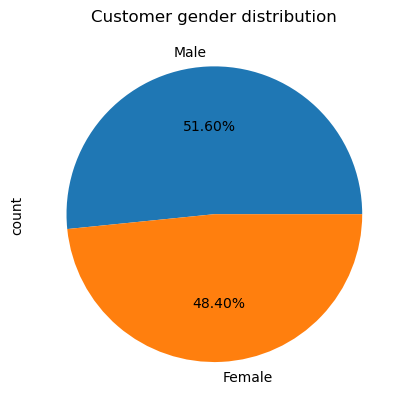

```python
df["Customer_Gender"].value_counts().plot(kind="pie",title="Customer gender distribution",autopct="%1.2f%%")
```

## interpretation

the chart indicates that both male and female customers are almost equal in number,with male customers being slightly higher than female customers.

```python
df["Age_Group"].value_counts()
```

```
Age_Group
Adults (35-64)          55358
Young Adults (25-34)    38299
Youth (<25)             17660
Seniors (64+)             719
Name: count, dtype: int64
```

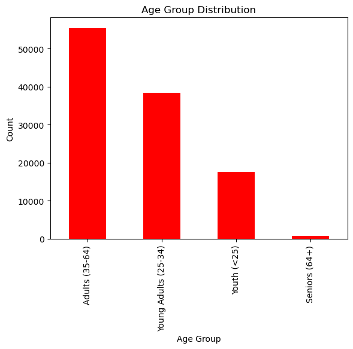

```python
df["Age_Group"].value_counts().plot(kind="bar",title="Age Group Distribution",color="red",xlabel="Age Group",ylabel="Count")
```

## interpretation

the chart shows that **Adults** have the highest number of customers,while**Seniors** have the lowest.**Young Adults** and **Youth** are in between.

```python
df["Product_Category"].value_counts()
```

```
Product_Category
Accessories    69312
Bikes          25794
Clothing       16930
Name: count, dtype: int64
```

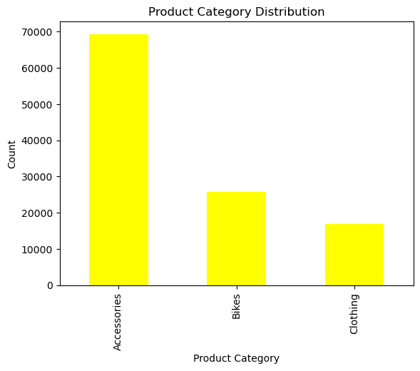

```python
df["Product_Category"].value_counts().plot(kind="bar",title="Product Category Distribution",color="Yellow",xlabel="Product Category",ylabel="Count")
```

## interpretation

the chart show that **Accessories** has the highest number of sales,while **Clothing** has the lowest number of sales.

```python
df["Country"].value_counts()
```

```
Country
United States     38840
Australia         23736
Canada            14027
United Kingdom    13486
Germany           11027
France            10920
Name: count, dtype: int64
```

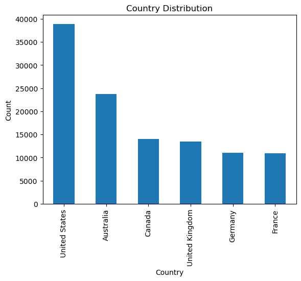

```python
df["Country"].value_counts().plot(kind="bar",title="Country Distribution",xlabel="Country",ylabel="Count")
```

## interpretation

the chart indicates that the **United States** has the highest number of sales records, while **France** has the lowest.Although **Germany** has the slightly more sales records than **France**, the difference between the two countries is minimal.

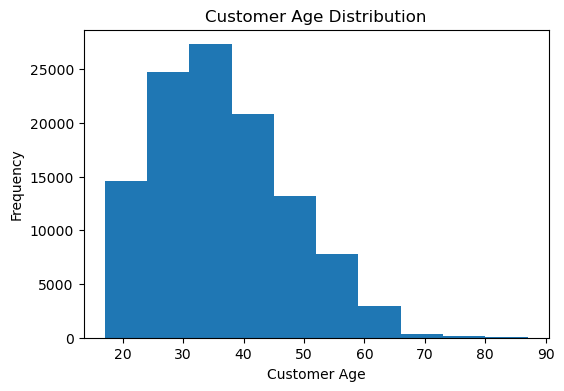

```python
plt.figure(figsize=(6,4))
plt.hist(df["Customer_Age"], bins=10)
plt.title("Customer Age Distribution")
plt.xlabel("Customer Age")
plt.ylabel("Frequency")
plt.show()
```

## interpretation

The histogram shows that most customers are between **25 and 40** years of age. The number of customers gradually decreases in the higher age groups, indicating that fewer customers are above **60 years**.

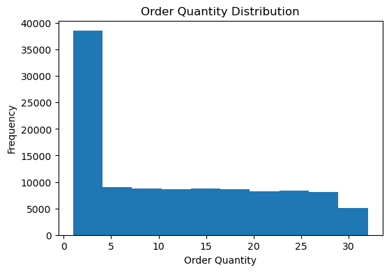

```python
plt.figure(figsize=(6,4))
plt.hist(df["Order_Quantity"], bins=10)
plt.title("Order Quantity Distribution")
plt.xlabel("Order Quantity")
plt.ylabel("Frequency")
plt.show()
```

## interpretation

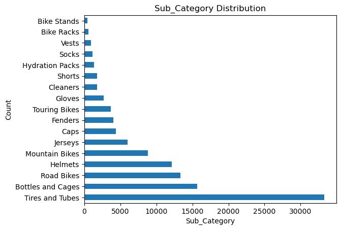

```python
df["Sub_Category"].value_counts().plot(kind="barh",title="Sub_Category Distribution",xlabel="Sub_Category",ylabel="Count")
```

## interpretation

The chart shows that **Tires and Tubes** is the most common sub-category in the dataset, while **Bike Stands** is the least common sub-category. This indicates that Tires and Tubes have the highest representation, whereas Bike Stands have the lowest representation.

## Bivariate Analysis

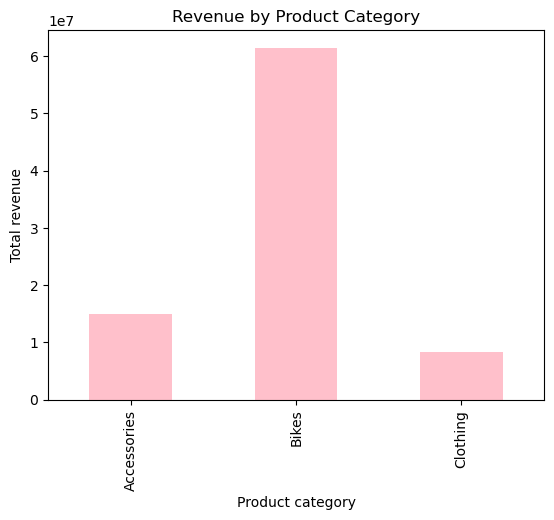

```python
df.groupby("Product_Category")["Revenue"].sum().plot(kind="bar",title="Revenue by Product Category",color="Pink",xlabel="Product category",ylabel="Total revenue")
```

## interpretation

the chart shows that **Bikes** generate the highest revenue, while **Clothing** generates the lowest revenue. this indicates that bikes contribute the most to the overall revenue.

```python
df.groupby("Country")["Revenue"].sum()
```

```
Country
Australia         21196395
Canada             7906182
France             8414745
Germany            8956724
United Kingdom    10575628
United States     27777098
Name: Revenue, dtype: int64
```

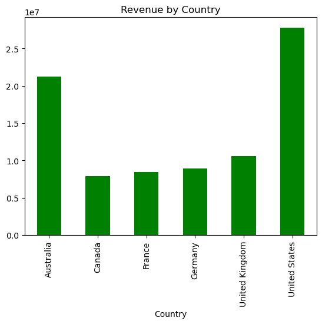

```python
df.groupby("Country")["Revenue"].sum().plot(kind="bar",title="Revenue by Country",color="green")
```

## interpretation

the chart shows that the **United States** generates the highest revenue,followed by **Australia**. **Canada** has the lowest revenue among all countries, while **Germany**, **France** and the **United Kingdom** generate moderate revenue.

```python
df.groupby("Product")["Order_Quantity"].sum()
```

```
Product
AWC Logo Cap                   67316
All-Purpose Bike Stand          2391
Bike Wash - Dissolver          27579
Classic Vest, L                 4651
Classic Vest, M                 4876
                               ...
Touring-3000 Yellow, 62           83
Water Bottle - 30 oz.         162051
Women's Mountain Shorts, L      7620
Women's Mountain Shorts, M     10317
Women's Mountain Shorts, S      9273
Name: Order_Quantity, Length: 130, dtype: int64
```

```python
df.groupby("Product")["Order_Quantity"].sum().sort_values(ascending=False)
```

```
Product
Water Bottle - 30 oz.      162051
Patch Kit/8 Patches        155310
Mountain Tire Tube         100915
AWC Logo Cap                67316
Sport-100 Helmet, Red       63652
                            ...
Mountain-100 Black, 42         72
Touring-3000 Blue, 50          70
Mountain-500 Silver, 48        52
Road-650 Red, 52               52
Mountain-500 Black, 52         40
Name: Order_Quantity, Length: 130, dtype: int64
```

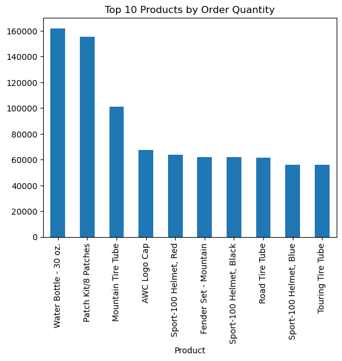

```python
df.groupby("Product")["Order_Quantity"].sum().sort_values(ascending=False).head(10).plot(kind="bar",title="Top 10 Products by Order Quantity")
```

## interpretation

The chart shows that **Water Bottle** is the best-selling product with the highest order quantity. The remaining products have comparatively lower order quantities.

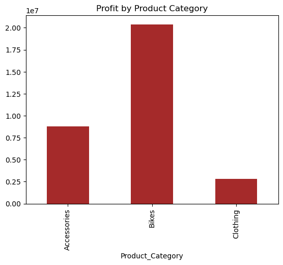

```python
df.groupby("Product_Category")["Profit"].sum().plot(kind="bar",title="Profit by Product Category",color="brown")
```

## interpretation

The chart shows that **Bikes** generate the highest profit, **Accessories** generate a moderate profit, and **Clothing** generates the lowest profit.

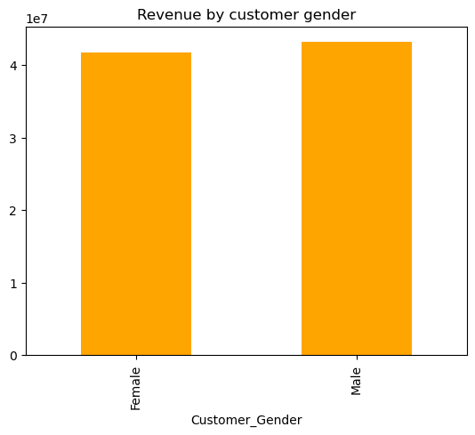

```python
df.groupby("Customer_Gender")["Revenue"].sum().plot(kind="bar",title="Revenue by customer gender",color="orange")
```

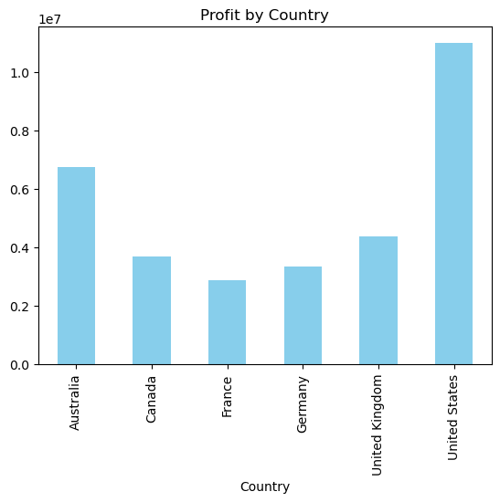

```python
df.groupby("Country")["Profit"].sum().plot(kind="bar",title="Profit by Country",color="skyblue")
```

## interpretation

The chart shows that **the United States** generates the highest profit, while **France** generates the lowest profit. The other countries generate moderate profit.

## Multivariate

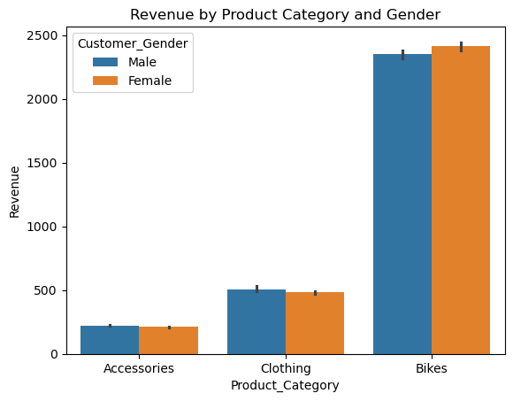

```python
sns.barplot(data=df,x="Product_Category",y="Revenue",hue="Customer_Gender")
plt.title("Revenue by Product Category and Gender")
```

## interpretation

This chart shows the revenue generated by different product categories based on customer gender. Bikes have the highest revenue, followed by Clothing, while Accessories have the lowest revenue. It also shows the contribution of male and female customers in each product category.

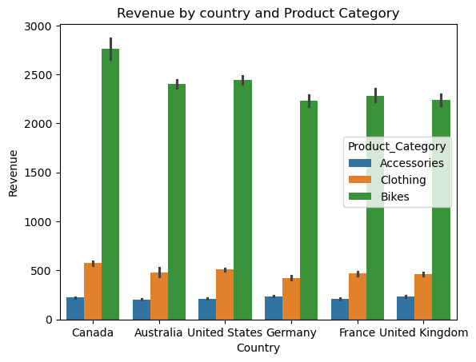

```python
sns.barplot(data=df,x="Country",y="Revenue",hue="Product_Category")
plt.title("Revenue by country and Product Category")
```

## interpretation

The chart compares revenue performance across countries and product categories. It highlights the contribution of different product categories in each country and helps identify high-performing markets and customer preferences.

```python
df.columns
```

```
Index(['Date', 'Day', 'Month', 'Year', 'Customer_Age', 'Age_Group',
       'Customer_Gender', 'Country', 'State', 'Product_Category',
       'Sub_Category', 'Product', 'Order_Quantity', 'Unit_Cost', 'Unit_Price',
       'Profit', 'Cost', 'Revenue'],
      dtype='object')
```

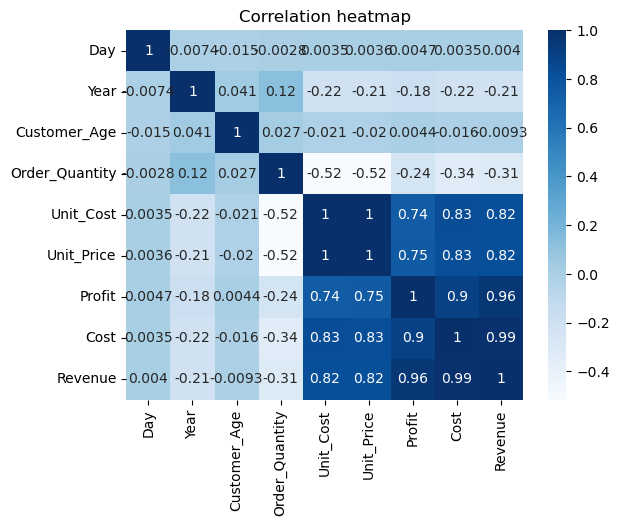

```python
sns.heatmap(df.corr(numeric_only=True),annot=True,cmap="Blues")
plt.title("Correlation heatmap")
plt.show()
```

## Conclusion

This EDA project analyzed the retail sales dataset using univariate, bivariate, multivariate, and correlation analysis. The analysis identified key sales patterns, customer behavior, product performance, and revenue trends. The insights gained from this analysis can help businesses make better decisions regarding products, customers, and overall sales performance.